# Projet_PMS

MOHAMEDAHMED-Mohmedlemine

2023-04-11

# Partie1 : Assurance maritime

### question1 :

#### Loi expontielle :

- Graphres des probabilites :
  $$\forall x \in \mathbf{R^{+}} ~ F(x)=P(X \leq x)
  = 1 - e^{-\lambda x}$$
  $$\forall x \in
  \mathbf{R^{+}} ~ ln(1-F(x))=-\lambda x$$
  le graphe de probabilites de loi expontielle est le nuage des points :

$$\{x_i^{*}, ln(1- \frac{i}{n})\} ~ pour~
i\in \{1,2,3,...,n-1 \}$$

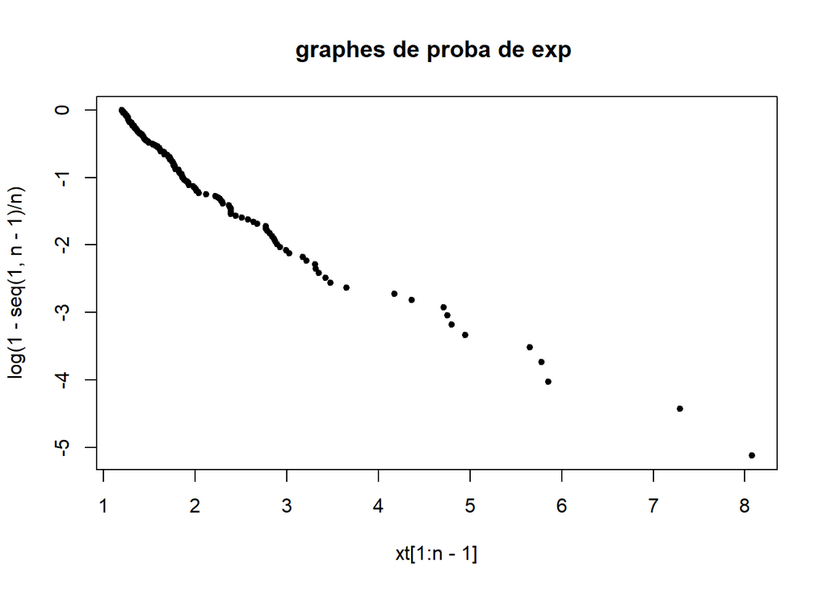

```r
    x <-scan("sinistres.csv")
    n <- length(x)
    xt <- sort(x)
    plot(xt[1:n-1],log(1-seq(1,n-1)/n),main="graphes de proba de exp ",xlim=c(xt[1],xt[n-1]),pch=20)
```

Le non alignement des points dans le graphe ci-dessus montre bien que la loi exponentielle n’est pas un modèle plausible pour décrire les montants des sinistres.

- Histogrammes pour la loi exponentielle:

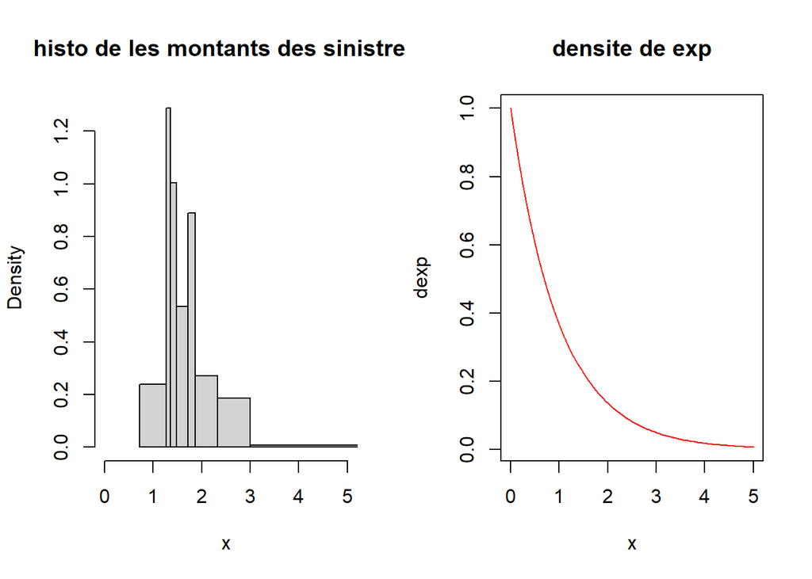

```r
x <-scan("sinistres.csv")
n <- length(x)
k<-round(1+log2(n))
xt<-sort(x)
a0=xt[1]-0.025*(xt[n]-xt[1])
ak=xt[n]+0.025*(xt[n]-xt[1])
h<-(ak-a0)/n
bornes <- c(a0,quantile(x,seq(1,k-1)/k),ak)
par(mfcol=c(1,2))
hist(x,prob=T , breaks=bornes, main="histo de les montants des sinistres",xlim=c(0,5))
plot(dexp,main="densite de exp" ,xlim=c(0,5), col="red",pch=20)
```

l’histogramme donne une approximation de la densite de la loi correspondante.  
le graphe ci-dessus montre bien que la loi exponentielle n’est pas un modèle plausible pour décrire les montants des sinistres.

#### Loi normale :

- Graphres des probabilites :
  si La variable aléatoire $X$ suit une loi normale de moyenne $\mu$ et d’écart type $\sigma$ $X \sim \mathcal{N}(\mu,\,\sigma^{2})$ Alors
  :
  $$\frac{X-m}{\sigma} ~ suit ~ une ~ loi ~
  \mathcal{N}(0,1)$$

$$\forall x \in \mathbf{R} ~ F(x)=P(X \leq
x) = P(\frac{X-m}{\sigma} \leq \frac{x-m}{\sigma} )$$
Donc
$$\forall x \in \mathbf{R} ~
\phi^{-1}(F(x))=\frac{1}{\sigma}x-\frac{m}{\sigma}$$
ou $\phi$ est la fonction de répartion de la loi $\mathcal{N}(0,1)$

Donc le graphe de probabilites de loi normale est le nuage des points :

$$\{x_i^{*}, \phi^{-1}(\frac{i}{n}) \} ~
pour~ i\in \{1,2,3,...,n-1 \}$$

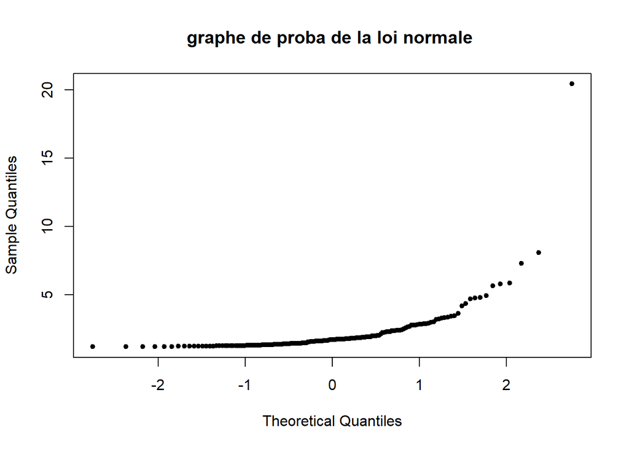

```r
qqnorm(x,pch=20,main="graphe de proba de la loi normale ")
```

Le non alignement des points dans le graphe ci-dessus montre bien que la loi normalle n’est pas un modèle plausible pour décrire les montants des sinistres.

Histogrammes pour la loi normale :

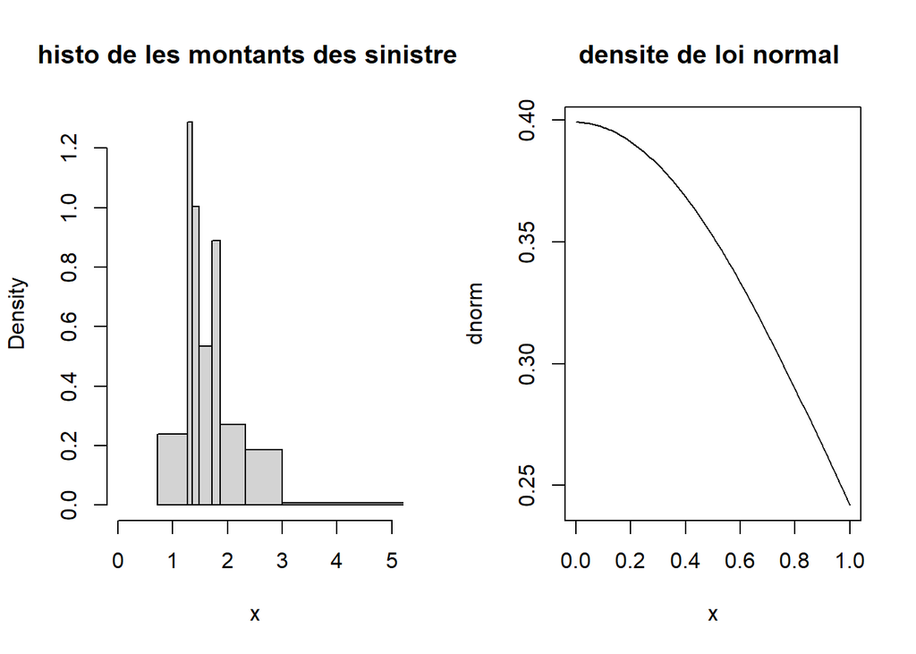

```r
par(mfcol=c(1,2))
hist(x,prob=T , breaks=bornes, main="histo de les montants des sinistres",xlim=c(0,5))
plot(dnorm,main="densite de loi normal ",pch=20)
```

l’histogramme donne une approximation de la densite de la loi correspondante .  
le graphe ci-dessus montre bien que la loi normale n’est pas un modèle plausible pour décrire les montants des sinistres.

### Question 2

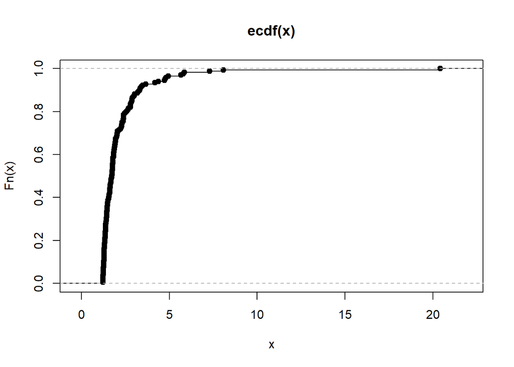

```r
plot(ecdf(x))
```

```r
# la moyenne empiriqué
moyenne <- mean(x)
moyenne
```

```
## [1] 2.167946
```

```r
# la mediane empirique
med<-median(x)
med
```

```
## [1] 1.72
```

```r
#le min est le max
min(x)
```

```
## [1] 1.201
```

```r
max(x)
```

```
## [1] 20.43
```

```r
#"écart-type  empirique"
sd<-sqrt((n-1)/n)*sd(x)
sd
```

```
## [1] 1.799712
```

```r
cat("variance empirique")
```

```
## variance empirique
```

```r
((n-1)/n)*var(x)
```

```
## [1] 3.238964
```

```r
cat("le coefficient de varaition empiriqué ")
```

```
## le coefficient de varaition empiriqué
```

```r
cv<-sd/moyenne
cv
```

```
## [1] 0.8301461
```

### question 3

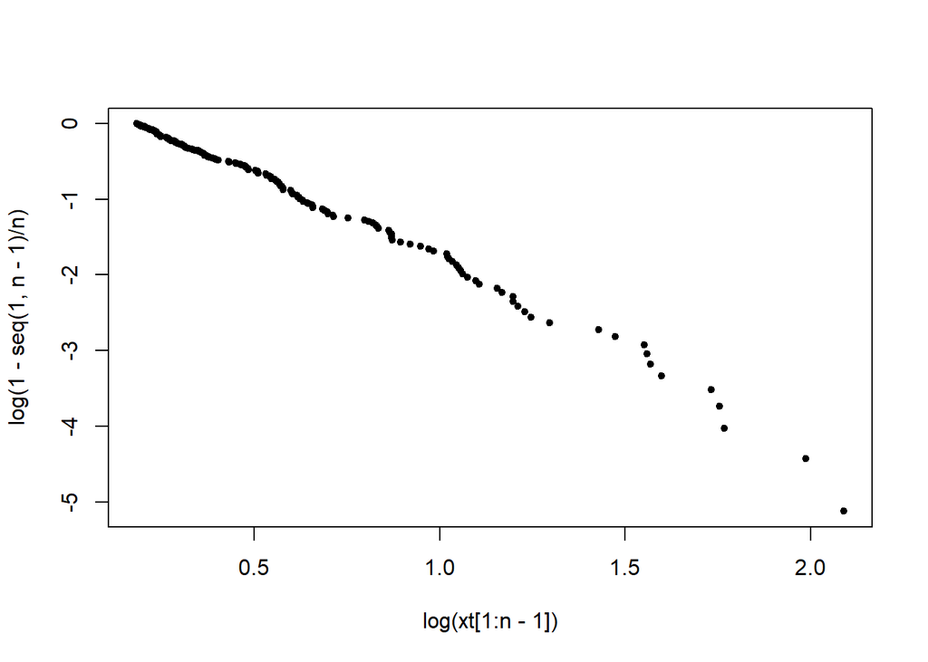

```r
xt <-sort(x)
plot(log(xt[1:n-1]),log(1-seq(1,n-1)/n),pch=20)
```

#### Partie2 :

### Question 1 :

```r
# Pour simuler une loi de P(a,b) on simule la loi exp(a)
simulation <- function(a,b,n)
{
  u <- runif(n,0,1) # on choisit une échantillon de [0,1]
  y <- -log(u)/a  # simulation d'une échantillon de taille de loi exp
  x <- b*exp(y)   #

  return(x)
}

# Test de notre fonction
l<-simulation(1,2,10)
l
```

```
##  [1] 11.771725  3.972062  2.027899  2.148494  3.793518  4.447273  4.234443
##  [8]  3.108889  3.484865  5.977500
```

### question 2